# R Notebook

# 15 statistical inference

# 15.1 polls

The general strategy is to interview a smaller group, chosen at random, and then infer the opinions of the entire population from the opinions of the smaller group. Statistical theory is used to justify the process. This theory is referred to as inference

# 15.1.1 the sampling model for polls

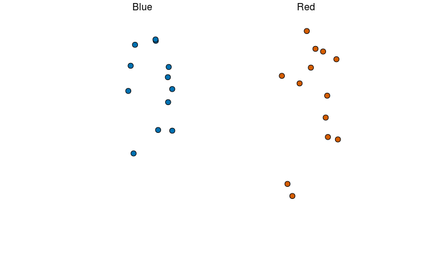

```r
library(tidyverse)
library(dslabs)
take_poll(25)
```

# 15.2 populations, samples,parameters,and estimates

We want to construct an estimate of p using only the information we observe. An estimate should be thought of as a summary of the observed data that we think is informative about the parameter of interest. It seems intuitive to think that the proportion of blue beads in the sample  
0.48 must be at least related to the actual proportion p . But do we simply predict p to be 0.48? First, remember that the sample proportion is a random variable. If we run the command take_poll(25) four times, we get a different answer each time, since the sample proportion is a random variable.

# 15.2.1 the sample average

For simplicity, let’s assume that the draws are independent: after we see each sampled bead, we return it to the urn. In this case, what do we know about the distribution of the sum of draws? First, we know that the expected value of the sum of draws is N times the average of the values in the urn. We know that the average of the 0s and 1s in the urn must be p , the proportion of blue beads.

# 15.2.2 parameters

We define the parameters p to represent this quantity. p is the average of the urn because if we take the average of the 1s (blue) and 0s (red), we get the proportion of blue beads. Since our main goal is figuring out what is  
p , we are going to estimate this parameter.

# 15.2.3 polling versus forecasting

forecasters try to build tools that model how opinions vary across time and try to predict the election night results taking into consideration the fact that opinions fluctuate.

# 15.2.4 properties of our estimate: expected value and standard error

This result reveals the power of polls. The expected value of the sample proportion X is the parameter of interest  
p and we can make the standard error as small as we want by increasing  
N . The law of large numbers tells us that with a large enough poll, our estimate converges to p .

```r
sqrt(p*(1-p))/sqrt(1000)
```

```
[1] 0.005394442
```

# 15.3 exercises

1.Suppose you poll a population in which a proportion p of voters are Democrats and 1−p are Republicans. Your sample size is N=25 . Consider the random variable S which is the total number of Democrats in your sample. What is the expected value of this random variable? Hint: it’s a function of p .

2.What is the standard error of S ? Hint: it’s a function of p .

sqrt(25)*sqrt(p*(1-p))

3.Consider the random variable S/N . This is equivalent to the sample average, which we have been denoting as  
¯X . What is the expected value of the ¯X ? Hint: it’s a function of p .

p

4.What is the standard error of ¯X ? Hint: it’s a function of p .

sqrt(p(1-p)/n)

5. Write a line of code that gives you the standard error se for the problem above for several values of  
   p , specifically for p <- seq(0, 1, length = 100). Make a plot of se versus p.

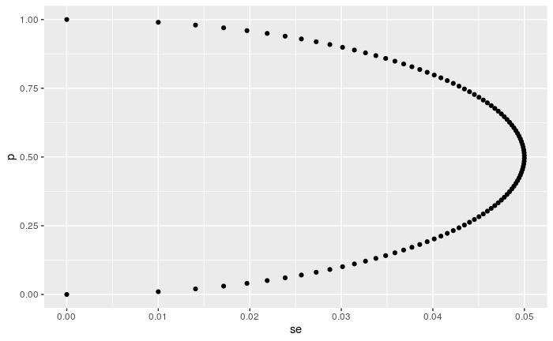

```r
p <- seq(0, 1, length = 100)
se<-sqrt(p*(1-p)/100)
library(tidyverse)
qplot(se,p)
```

6.Copy the code above and put it inside a for-loop to make the plot for  
N=25 , N=100 , and N=1000 .

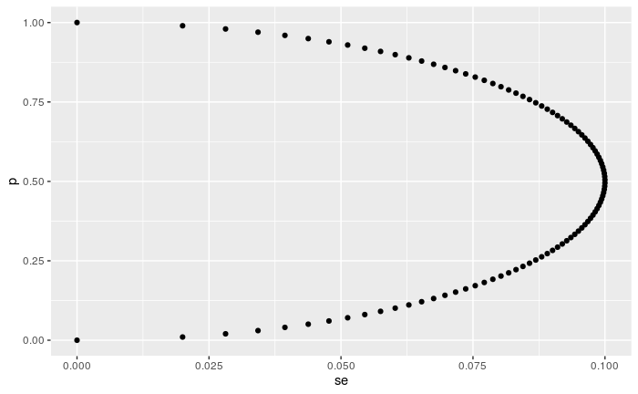

```r
p <- seq(0, 1, length = 100)
se<-sqrt(p*(1-p)/25)
library(tidyverse)
qplot(se,p)
```

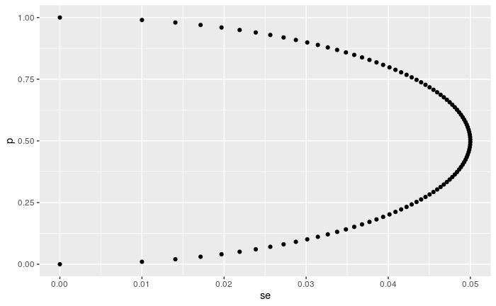

```r
p <- seq(0, 1, length = 100)
se<-sqrt(p*(1-p)/100)
library(tidyverse)
qplot(se,p)
```

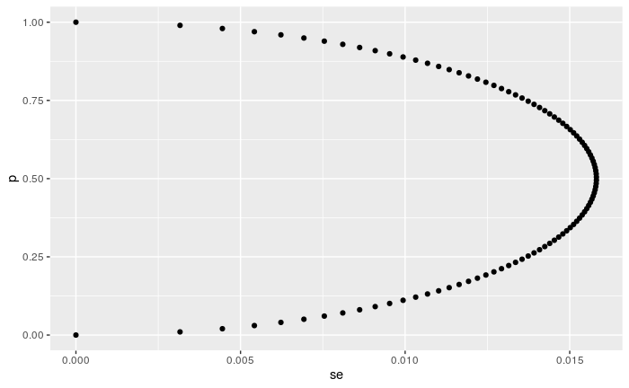

```r
p <- seq(0, 1, length = 100)
se<-sqrt(p*(1-p)/1000)
library(tidyverse)
qplot(se,p)
```

7.If we are interested in the difference in proportions, p−(1−p) , our estimate is d=¯X−(1−¯X) . Use the rules we learned about sums of random variables and scaled random variables to derive the expected value of d .

2p-1

8. What is the standard error of d ?

2*sqrt(p(1−p)/n)

9.If the actual p=.45 , it means the Republicans are winning by a relatively large margin since d=−.1 , which is a 10% margin of victory. In this case, what is the standard error of 2^X−1 if we take a sample of N=25 ?

```r
n <- 25
p <- 0.45

2*sqrt(p*(1-p)/n)
```

```
[1] 0.1989975
```

10.Given the answer to 9, which of the following best describes your strategy of using a sample size of N=25 ?

a.The expected value of our estimate 2¯X−1 is d , so our prediction will be right on. b.Our standard error is larger than the difference, so the chances of 2¯X−1 being positive and throwing us off were not that small. We should pick a larger sample size. c.The difference is 10% and the standard error is about 0.2, therefore much smaller than the difference. d.Because we don’t know p , we have no way of knowing that making N larger would actually improve our standard error.

b

# 15.4 central limit theorem in practice

```r
x_hat <- 0.48
se <- sqrt(x_hat*(1-x_hat)/25)
se
```

```
[1] 0.09991997
```

```r
pnorm(0.01/se) - pnorm(-0.01/se)
```

```
[1] 0.07971926
```

```r
1.96*se
```

```
[1] 0.1958431
```

```r
pnorm(1.96)-pnorm(-1.96)
```

```
[1] 0.9500042
```

In summary, the CLT tells us that our poll based on a sample size of 25 is not very useful. We don’t really learn much when the margin of error is this large. All we can really say is that the popular vote will not be won by a large margin. This is why pollsters tend to use larger sample sizes.

# 15.4.1 a monte carlo simulation

```r
B <- 10000
N <- 1000
x_hat <- replicate(B, {
  x <- sample(c(0,1), size = N, replace = TRUE, prob = c(1-p, p))
  mean(x)
})
```

```r
p <- 0.45
N <- 1000

x <- sample(c(0,1), size = N, replace = TRUE, prob = c(1-p, p))
x_hat <- mean(x)
```

```r
B <- 10000
x_hat <- replicate(B, {
  x <- sample(c(0,1), size = N, replace = TRUE, prob = c(1-p, p))
  mean(x)
})
```

```r
mean(x_hat)
```

```
[1] 0.450043
```

```r
sd(x_hat)
```

```
[1] 0.0155532
```

# 15.4.2 the spread

Once we have our estimate ¯X and ^SE(¯X) , we estimate the spread with 2¯X−1 and, since we are multiplying by 2, the standard error is 2^SE(¯X) . Note that subtracting 1 does not add any variability so it does not affect the standard error.

# 15.4.3 bias:why not run a very large poll?

One reason is that running such a poll is very expensive. Another possibly more important reason is that theory has its limitations. Polling is much more complicated than picking beads from an urn.

# 15.5 exercises

1. Write an urn model function that takes the proportion of Democrats p and the sample size N as arguments and returns the sample average if Democrats are 1s and Republicans are 0s. Call the function take_sample.

```r
take_sample <- function(p, N){
  X <- sample(c(0,1), size = N, replace = TRUE, prob = c(1 - p, p))
  mean(X)
}
```

2.Now assume p <- 0.45 and that your sample size is N=100 . Take a sample 10,000 times and save the vector of mean(X) - p into an object called errors. Hint: use the function you wrote for exercise 1 to write this in one line of code.

```r
p <- 0.45
N <- 100
B <- 10000
errors <- replicate(B, take_sample(p, N) - p)
```

3. The vector errors contains, for each simulated sample, the difference between the actual p and our estimate  
   ¯X . We refer to this difference as the error. Compute the average and make a histogram of the errors generated in the Monte Carlo simulation and select which of the following best describes their distributions:

```r
mean(errors)
```

```
[1] -0.000302
```

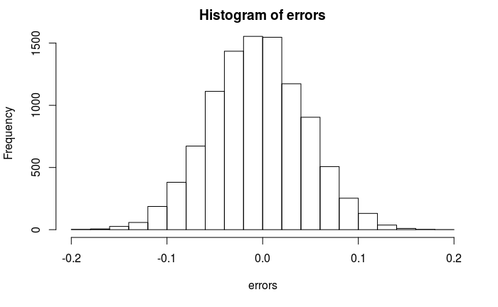

```r
hist(errors)
```

a.The errors are all about 0.05. b.The errors are all about -0.05. c.The errors are symmetrically distributed around 0. d.The errors range from -1 to 1.

c

4.The error ¯X-p is a random variable. In practice, the error is not observed because we do not know p . Here we observe it because we constructed the simulation. What is the average size of the error if we define the size by taking the absolute value ∣¯X−p∣ ?

```r
mean(abs(errors))
```

```
[1] 0.03967
```

5. The standard error is related to the typical size of the error we make when predicting. We say size because we just saw that the errors are centered around 0, so thus the average error value is 0. For mathematical reasons related to the Central Limit Theorem, we actually use the standard deviation of errors rather than the average of the absolute values to quantify the typical size. What is this standard deviation of the errors?

```r
sqrt(mean(errors^2))
```

```
[1] 0.0498
```

6.The theory we just learned tells us what this standard deviation is going to be because it is the standard error of  
¯X . What does theory tell us is the standard error of ¯X for a sample size of 100?

```r
sqrt(p*(1-p)/100)
```

```
[1] 0.04974937
```

7. In practice, we don’t know p , so we construct an estimate of the theoretical prediction based by plugging in  
   ¯X for p . Compute this estimate. Set the seed at 1 with set.seed(1).

```r
set.seed(1)
X <- sample(0:1, N, replace=T, p=c(1-p,p))
X_bar <- mean(X)
sqrt(X_bar*(1-X_bar)/N)
```

```
[1] 0.04983974
```

8.Note how close the standard error estimates obtained from the Monte Carlo simulation (exercise 5), the theoretical prediction (exercise 6), and the estimate of the theoretical prediction (exercise 7) are. The theory is working and it gives us a practical approach to knowing the typical error we will make if we predict p with ¯X . Another advantage that the theoretical result provides is that it gives an idea of how large a sample size is required to obtain the precision we need. Earlier we learned that the largest standard errors occur for p=0.5 . Create a plot of the largest standard error for N ranging from 100 to 5,000. Based on this plot, how large does the sample size have to be to have a standard error of about 1%?

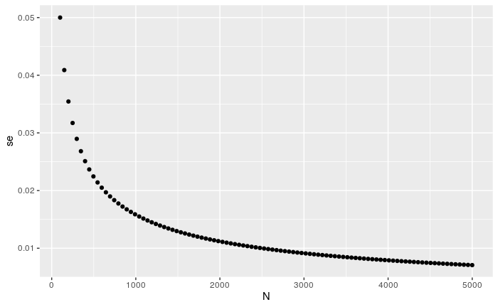

```r
N <- seq(100, 5000, len = 100)
p <- 0.5
se <- sqrt(p*(1-p)/N)
library(tidyverse)
qplot(N,se)
```

a.100 b.500 c.2,500 d.4,000

c

9. For sample size N=100, the central limit theorem tells us that the distribution of X¯ is: a.practically equal to p . b.approximately normal with expected value p and standard error √p(1−p)/N . c.approximately normal with expected value ¯X and standard error √¯X(1−¯X)/N . d.not a random variable.

b

10.Based on the answer from exercise 8, the error ¯X−p is: a.practically equal to 0. b.approximately normal with expected value 0 and standard error √p(1−p)/N . c.approximately normal with expected value p and standard error √p(1−p)/N . d.not a random variable.

b

11.To corroborate your answer to exercise 9, make a qq-plot of the errors you generated in exercise 2 to see if they follow a normal distribution.

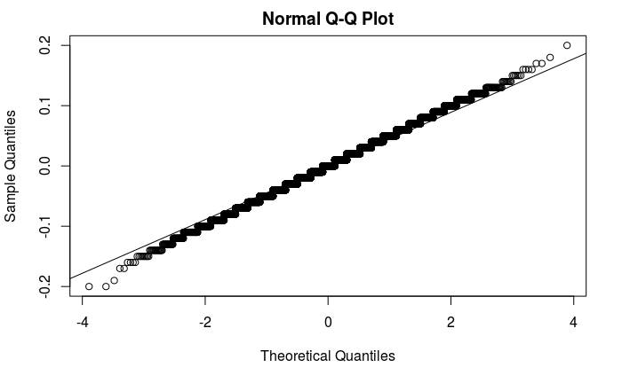

```r
qqnorm(errors)
qqline(errors)
```

12.If p=0.45 and N=100 as in exercise 2, use the CLT to estimate the probability that ¯X>0.5 . You can assume you know p=0.45 for this calculation.

```r
p <- 0.45
N <- 100
1-pnorm(0.5, p, sqrt(p*(1-p)/N))
```

```
[1] 0.1574393
```

13.Assume you are in a practical situation and you don’t know p . Take a sample of size N=100 and obtain a sample average of ¯X=0.51 . What is the CLT approximation for the probability that your error is equal to or larger than 0.01?

```r
X_hat <- 0.51
se_hat <- sqrt(X_hat*(1-X_hat)/N)
1 - pnorm(0.01, 0, se_hat) + pnorm(-0.01, 0, se_hat)
```

```
[1] 0.8414493
```

# 15.6 confidence intervals

```r
p <- 0.45
N <- 1000
```

```r
x <- sample(c(0, 1), size = N, replace = TRUE, prob = c(1-p, p))
x_hat <- mean(x)
se_hat <- sqrt(x_hat * (1 - x_hat) / N)
c(x_hat - 1.96 * se_hat, x_hat + 1.96 * se_hat)
```

```
[1] 0.3973327 0.4586673
```

```r
x <- sample(c(0,1), size=N, replace=TRUE, prob=c(1-p, p))
x_hat <- mean(x)
se_hat <- sqrt(x_hat * (1 - x_hat) / N)
c(x_hat - 1.96 * se_hat, x_hat + 1.96 * se_hat)
```

```
[1] 0.4151909 0.4768091
```

```r
pnorm(1.96) - pnorm(-1.96)
```

```
[1] 0.9500042
```

```r
z <- qnorm(0.995)
z
```

```
[1] 2.575829
```

```r
pnorm(z) - pnorm(-z)
```

```
[1] 0.99
```

```r
qnorm(0.975)
```

```
[1] 1.959964
```

# 15.6.1 a monte carlo simulation

```r
N <- 1000
B <- 10000
inside <- replicate(B, {
  x <- sample(c(0,1), size = N, replace = TRUE, prob = c(1-p, p))
  x_hat <- mean(x)
  se_hat <- sqrt(x_hat * (1 - x_hat) / N)
  between(p, x_hat - 1.96 * se_hat, x_hat + 1.96 * se_hat)
})
mean(inside)
```

```
[1] 0.9473
```

# 15.6.2 the correct language

# 15.7 exercises

```r
library(dslabs)
data("polls_us_election_2016")
```

```r
library(tidyverse)
polls <- polls_us_election_2016 %>%
  filter(enddate >= "2016-10-31" & state == "U.S.")
```

1.For the first poll, you can obtain the samples size and estimated Clinton percentage with:

```r
N <- polls$samplesize[1]
x_hat <- polls$rawpoll_clinton[1]/100
```

Assume there are only two candidates and construct a 95% confidence interval for the election night proportion p .

```r
se_hat <- sqrt(X_hat*(1-X_hat)/N)
X_hat +  c(-1,1)*pnorm(0.975)*se_hat
```

[output not shown]

2.Now use dplyr to add a confidence interval as two columns, call them lower and upper, of the object poll, then show a pollster. Show the end date, pollster, the estimated proportion, and confidence interval columns. Hint: define temporary columns X_hat and se_hat.

```r
library(tidyverse)
polls %>% mutate(X_hat = polls$rawpoll_clinton/100, se_hat = sqrt(X_hat*(1-X_hat)/samplesize),
                 lower = X_hat - pnorm(0.975)*se_hat, upper = X_hat + pnorm(0.975)*se_hat) %>%
  select(pollster, enddate, X_hat, lower, upper)
```

| pollster | enddate | X_hat | lower | upper |
| --- | --- | --- | --- | --- |
| ABC News/Washington Post | 2016-11-06 | 0.4700 | 0.4611527 | 0.4788473 |
| Google Consumer Surveys | 2016-11-07 | 0.3803 | 0.3778127 | 0.3827873 |
| Ipsos | 2016-11-06 | 0.4200 | 0.4112012 | 0.4287988 |
| YouGov | 2016-11-07 | 0.4500 | 0.4431476 | 0.4568524 |
| Gravis Marketing | 2016-11-06 | 0.4700 | 0.4667684 | 0.4732316 |
| Fox News/Anderson Robbins Research/Shaw & Company Research | 2016-11-06 | 0.4800 | 0.4684045 | 0.4915955 |
| CBS News/New York Times | 2016-11-06 | 0.4500 | 0.4389966 | 0.4610034 |
| NBC News/Wall Street Journal | 2016-11-05 | 0.4400 | 0.4284208 | 0.4515792 |
| IBD/TIPP | 2016-11-07 | 0.4120 | 0.3996444 | 0.4243556 |
| Selzer & Company | 2016-11-06 | 0.4400 | 0.4253328 | 0.4546672 |

[output cut: 60 more lines]

3.The final tally for the popular vote was Clinton 48.2% and Trump 46.1%. Add a column, call it hit, to the previous table stating if the confidence interval included the true proportion p=0.482 or not.

```r
polls %>% mutate(X_hat = polls$rawpoll_clinton/100, se_hat = sqrt(X_hat*(1-X_hat)/samplesize),
                 lower = X_hat - pnorm(0.975)*se_hat, upper = X_hat + pnorm(0.975)*se_hat,
                 hit = lower<=0.482 & upper>=0.482) %>%
  select(pollster, enddate, X_hat, lower, upper, hit)
```

| pollster | enddate | X_hat | lower | upper | hit |
| --- | --- | --- | --- | --- | --- |
| ABC News/Washington Post | 2016-11-06 | 0.4700 | 0.4611527 | 0.4788473 | FALSE |
| Google Consumer Surveys | 2016-11-07 | 0.3803 | 0.3778127 | 0.3827873 | FALSE |
| Ipsos | 2016-11-06 | 0.4200 | 0.4112012 | 0.4287988 | FALSE |
| YouGov | 2016-11-07 | 0.4500 | 0.4431476 | 0.4568524 | FALSE |
| Gravis Marketing | 2016-11-06 | 0.4700 | 0.4667684 | 0.4732316 | FALSE |
| Fox News/Anderson Robbins Research/Shaw & Company Research | 2016-11-06 | 0.4800 | 0.4684045 | 0.4915955 | TRUE |
| CBS News/New York Times | 2016-11-06 | 0.4500 | 0.4389966 | 0.4610034 | FALSE |
| NBC News/Wall Street Journal | 2016-11-05 | 0.4400 | 0.4284208 | 0.4515792 | FALSE |
| IBD/TIPP | 2016-11-07 | 0.4120 | 0.3996444 | 0.4243556 | FALSE |
| Selzer & Company | 2016-11-06 | 0.4400 | 0.4253328 | 0.4546672 | FALSE |

[output cut: 60 more lines]

4.For the table you just created, what proportion of confidence intervals included p ?

| mean(hit) |
| --- |
| 0.1857143 |

5. If these confidence intervals are constructed correctly, and the theory holds up, what proportion should include p ?

```r
0.95
```

6. A much smaller proportion of the polls than expected produce confidence intervals containing p . If you look closely at the table, you will see that most polls that fail to include p are underestimating. The reason for this is undecided voters, individuals polled that do not yet know who they will vote for or do not want to say. Because, historically, undecideds divide evenly between the two main candidates on election day, it is more informative to estimate the spread or the difference between the proportion of two candidates d , which in this election was 0.482−0.461=0.021 . Assume that there are only two parties and that d=2p−1 , redefine polls as below and re-do exercise 1, but for the difference.

```r
polls <- polls_us_election_2016 %>%
  filter(enddate >= "2016-10-31" & state == "U.S.")  %>%
  mutate(d_hat = rawpoll_clinton / 100 - rawpoll_trump / 100)
```

```r
N <- polls$samplesize[1]
d_hat <- polls$d_hat[1]
X_hat <- (d_hat+1)/2
se_hat <- 2*sqrt(X_hat*(1-X_hat)/N)
d_hat + c(-1,1)*pnorm(0.975)*se_hat
```

```
[1] 0.02228763 0.05771237
```

7.Now repeat exercise 3, but for the difference.

```r
polls %>% mutate(X_hat = (d_hat+1)/2, se_hat = 2*sqrt(X_hat*(1-X_hat)/samplesize),
                 lower = d_hat - pnorm(0.975)*se_hat, upper = d_hat + pnorm(0.975)*se_hat,
                 hit = lower<=0.021 & upper>=0.021) %>%
  select(pollster, enddate, d_hat, lower, upper, hit)
```

| pollster | enddate | d_hat | lower | upper | hit |
| --- | --- | --- | --- | --- | --- |
| ABC News/Washington Post | 2016-11-06 | 0.0400 | 0.0222876324 | 0.057712368 | FALSE |
| Google Consumer Surveys | 2016-11-07 | 0.0234 | 0.0182778367 | 0.028522163 | TRUE |
| Ipsos | 2016-11-06 | 0.0300 | 0.0121808069 | 0.047819193 | TRUE |
| YouGov | 2016-11-07 | 0.0400 | 0.0262372162 | 0.053762784 | FALSE |
| Gravis Marketing | 2016-11-06 | 0.0400 | 0.0335302203 | 0.046469780 | FALSE |
| Fox News/Anderson Robbins Research/Shaw & Company Research | 2016-11-06 | 0.0400 | 0.0168090671 | 0.063190933 | TRUE |
| CBS News/New York Times | 2016-11-06 | 0.0400 | 0.0178999457 | 0.062100054 | TRUE |
| NBC News/Wall Street Journal | 2016-11-05 | 0.0400 | 0.0166917809 | 0.063308219 | TRUE |
| IBD/TIPP | 2016-11-07 | -0.0150 | -0.0401002556 | 0.010100256 | FALSE |
| Selzer & Company | 2016-11-06 | 0.0300 | 0.0004653446 | 0.059534655 | TRUE |

[output cut: 60 more lines]

8. Now repeat exercise 4, but for the difference.

```r
polls %>% mutate(X_hat = (d_hat+1)/2, se_hat = 2*sqrt(X_hat*(1-X_hat)/samplesize),
                 lower = d_hat - pnorm(0.975)*se_hat, upper = d_hat + pnorm(0.975)*se_hat,
                 hit = lower<=0.021 & upper>=0.021) %>%
  select(pollster, enddate, d_hat, lower, upper, hit) %>%
  summarize(mean(hit))
```

| mean(hit) |
| --- |
| 0.5428571 |

9.Although the proportion of confidence intervals goes up substantially, it is still lower than 0.95. In the next chapter, we learn the reason for this. To motivate this, make a plot of the error, the difference between each poll’s estimate and the actual  
d=0.021 . Stratify by pollster.

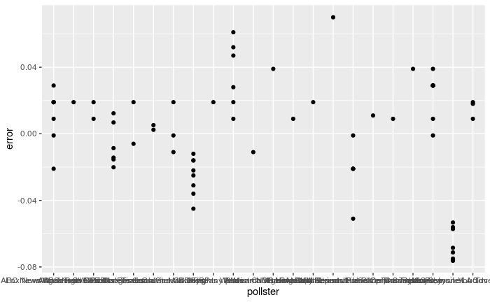

```r
polls %>% mutate(error = d_hat - 0.021) %>%
  ggplot(aes(pollster, error)) +
  geom_point()
```

10.Redo the plot that you made for exercise 9, but only for pollsters that took five or more polls.

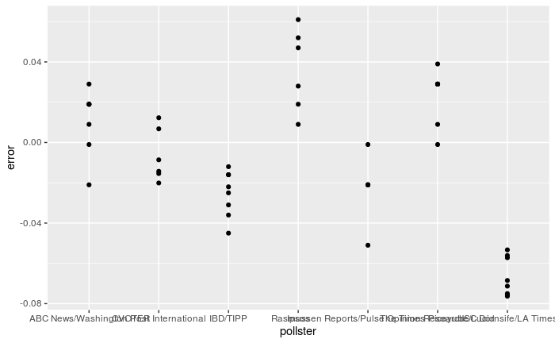

```r
polls %>% mutate(error = d_hat - 0.021) %>%
  group_by(pollster) %>%
  filter(n() >= 5) %>%
  ggplot(aes(pollster, error)) +
  geom_point()
```

# 15.8 power

```r
N <- 25
x_hat <- 0.48
(2 * x_hat - 1) + c(-1.96, 1.96) * 2 * sqrt(x_hat * (1 - x_hat) / N)
```

```
[1] -0.4316863  0.3516863
```

# 15.9 p-values

```r
N <- 100
z <- sqrt(N)*0.02/0.5
1 - (pnorm(z) - pnorm(-z))
```

```
[1] 0.6891565
```

# 15.10 association tests

```r
library(tidyverse)
library(dslabs)
data("research_funding_rates")
research_funding_rates %>% select(discipline, applications_total,
                                  success_rates_total) %>% head()
```

|  | discipline | applications_total | success_rates_total |
| --- | --- | --- | --- |
| 1 | Chemical sciences | 122 | 26.2 |
| 2 | Physical sciences | 174 | 20.1 |
| 3 | Physics | 76 | 26.3 |
| 4 | Humanities | 396 | 16.4 |
| 5 | Technical sciences | 251 | 17.1 |
| 6 | Interdisciplinary | 183 | 15.8 |

```r
names(research_funding_rates)
```

```
 [1] "discipline"          "applications_total"  "applications_men"    "applications_women"  "awards_total"
 [6] "awards_men"          "awards_women"        "success_rates_total" "success_rates_men"   "success_rates_women"
```

```r
totals <- research_funding_rates %>%
  select(-discipline) %>%
  summarize_all(sum) %>%
  summarize(yes_men = awards_men,
            no_men = applications_men - awards_men,
            yes_women = awards_women,
            no_women = applications_women - awards_women)
```

```r
totals %>% summarize(percent_men = yes_men/(yes_men+no_men),
                     percent_women = yes_women/(yes_women+no_women))
```

| percent_men | percent_women |
| --- | --- |
| 0.17737 | 0.1489899 |

# 15.10.1 lady tasting tea

As an example, suppose she picked 3 out of 4 correctly. Do we believe she has a special ability? The basic question we ask is: if the tester is actually guessing, what are the chances that she gets 3 or more correct? Just as we have done before, we can compute a probability under the null hypothesis that she is guessing 4 of each. Under this null hypothesis, we can think of this particular example as picking 4 balls out of an urn with 4 blue (correct answer) and 4 red (incorrect answer) balls.

# 15.10.2 two by two tables

```r
tab <- matrix(c(3,1,1,3),2,2)
rownames(tab)<-c("Poured Before","Poured After")
colnames(tab)<-c("Guessed before","Guessed after")
tab
```

```
              Guessed before Guessed after
Poured Before              3             1
Poured After               1             3
```

```r
fisher.test(tab, alternative="greater")$p.value
```

```
[1] 0.2428571
```

# 15.10.3 chi square test

```r
totals %>% summarize(percent_men = yes_men/(yes_men+no_men),
                     percent_women = yes_women/(yes_women+no_women))
```

| percent_men | percent_women |
| --- | --- |
| 0.17737 | 0.1489899 |

```r
rate <- totals %>%
  summarize(percent_total =
              (yes_men + yes_women)/
              (yes_men + no_men +yes_women + no_women)) %>%
  pull(percent_total)
rate
```

```
[1] 0.1654269
```

```r
two_by_two <- data.frame(awarded = c("no", "yes"),
                     men = c(totals$no_men, totals$yes_men),
                     women = c(totals$no_women, totals$yes_women))
two_by_two
```

| awarded | men | women |
| --- | --- | --- |
| no | 1345 | 1011 |
| yes | 290 | 177 |

```r
data.frame(awarded = c("no", "yes"),
       men = (totals$no_men + totals$yes_men) * c(1 - rate, rate),
       women = (totals$no_women + totals$yes_women) * c(1 - rate, rate))
```

| awarded | men | women |
| --- | --- | --- |
| no | 1364.5271 | 991.4729 |
| yes | 270.4729 | 196.5271 |

```r
chisq_test <- two_by_two %>% select(-awarded) %>% chisq.test()
```

```r
chisq_test$p.value
```

```
[1] 0.05091372
```

# 15.10.4 the odds ratio

```r
odds_men <- with(two_by_two, (men[2]/sum(men)) / (men[1]/sum(men)))
odds_men
```

```
[1] 0.2156134
```

```r
odds_women <- with(two_by_two, (women[2]/sum(women)) / (women[1]/sum(women)))
odds_women
```

```
[1] 0.1750742
```

```r
odds_men / odds_women
```

```
[1] 1.231554
```

# 15.10.5 confidence intervals for the odds ratio

```r
log_or <- log(odds_men / odds_women)
se <- two_by_two %>% select(-awarded) %>%
  summarize(se = sqrt(sum(1/men) + sum(1/women))) %>%
  pull(se)
ci <- log_or + c(-1,1) * qnorm(0.975) * se
```

```r
exp(ci)
```

```
[1] 1.004313 1.510213
```

```r
2*(1 - pnorm(log_or, 0, se))
```

```
[1] 0.0453586
```

# 15.10.6 small count correction

it is common practice to avoid 0s by adding 0.5 to each cell. This is referred to as the Haldane–Anscombe correction and has been shown, both in practice and theory, to work well.

# 15.10.7 large samples small p values

```r
two_by_two %>% select(-awarded) %>%
  mutate(men = men*10, women = women*10) %>%
  chisq.test() %>% .$p.value
```

```
[1] 2.625423e-10
```

# 15.11 exercises

1. A famous athlete has an impressive career, winning 70% of her 500 career matches. However, this athlete gets criticized because in important events, such as the Olympics, she has a losing record of 8 wins and 9 losses. Perform a Chi-square test to determine if this losing record can be simply due to chance as opposed to not performing well under pressure.

```r
two_by_two <- data.frame(cq = c('win', 'lose'), important = c(8, 9), normal = c(350-8, 150-9))
chisq_test <- two_by_two %>% select(-cq) %>% chisq.test()
chisq_test$p.value
```

```
[1] 0.06712074
```

2.Why did we use the Chi-square test instead of Fisher’s exact test in the previous exercise?

a.It actually does not matter, since they give the exact same p-value. b.Fisher’s exact and the Chi-square are different names for the same test. c.Because the sum of the rows and columns of the two-by-two table are not fixed so the hypergeometric distribution is not an appropriate assumption for the null hypothesis. For this reason, Fisher’s exact test is rarely applicable with observational data. d.Because the Chi-square test runs faster.

c

3.Compute the odds ratio of “losing under pressure” along with a confidence interval.

```r
odds_important <- with(two_by_two, (important[1]/sum(important)) / (important[2]/sum(important)))
odds_normal <- with(two_by_two, (normal[1]/sum(normal)) / (normal[2]/sum(normal)))
log_or <- log(odds_important / odds_normal)
se <- two_by_two %>% select(-cq) %>%
  summarize(se = sqrt(sum(1/important) + sum(1/normal))) %>%
  pull(se)
ci <- log_or + c(-1,1) * qnorm(0.975) * se
exp(ci)
```

```
[1] 0.1385955 0.9690182
```

4. Notice that the p-value is larger than 0.05 but the 95% confidence interval does not include 1. What explains this?

a.We made a mistake in our code. b.These are not t-tests so the connection between p-value and confidence intervals does not apply. c.Different approximations are used for the p-value and the confidence interval calculation. If we had a larger sample size the match would be better. d.We should use the Fisher exact test to get confidence intervals.

c

5. Multiply the two-by-two table by 2 and see if the p-value and confidence retrieval are a better match.

```r
two_by_two %>% select(-cq) %>%
  mutate(important = important*2, normal = normal*2) %>%
  chisq.test() %>% .$p.value
```

```
[1] 0.00544228
```

.